# EDA

Author

Jingda Yang

## Github URL

[Code Link](https://github.com/anly503/hw2-spring-2023-T1an-T1an) [Dataset](https://sorry.vse.cz/~berka/challenge/pkdd1999/tsumoto.htm)

## Data summary

The patient data in the Tsumoto dataset comes from three separate files: patient records, specialized lab tests, and laboratory tests that are kept in hospital information systems. Patient records include information on diagnosis and hospital admission in addition to demographic details like sex and birthdate. The findings of the particular laboratory tests include information on the patient’s symptoms, measurements of coagulation and the degree of thrombosis, and test results for various antibodies. The outcomes of common tests, such as measures of blood glucose and cholesterol, kidney and liver function, are maintained in hospital information systems as laboratory examination reports.

The whole dataset is intended to investigate collagen diseases, with a specific focus on coagulation problems. There are three distinct files that make up the document, and each one contains data from a different source. The patient information file contains information on demographics, diagnosis, and hospital admission, whereas the specific laboratory examinations file contains details on a variety of specialized laboratory tests. The third file, laboratory examinations stored in hospital information systems, contains details on common laboratory tests performed on patients. By combining the information from these files, researchers may discover a lot about the connections between coagulation issues, collagen diseases, and the outcomes of widespread laboratory tests.

## Initial questions

- Is there a difference in the degree of thrombosis between males and females?
- Does the degree of thrombosis vary across different age groups?
- Would the concentration of ANA and age have an impact on the patient (who was admitted to the hospital or followed at the outpatient clinic)?
- Does the degree of thrombosis relate to IGG, IGM, and IGA?

## Data munging

```python
import missingno as msno
import pandas as pd
import numpy as np
import matplotlib.pyplot as plt
from mpl_toolkits.mplot3d import Axes3D
import seaborn as sns
import warnings

# Ignore all warning messages
warnings.filterwarnings("ignore")
```

```python
# Read the data
tsumoto_a = pd.read_csv('./data/TSUMOTO_A.CSV', encoding='unicode_escape')
tsumoto_b = pd.read_csv('./data/TSUMOTO_B.CSV', encoding='unicode_escape')
tsumoto_c = pd.read_csv('./data/TSUMOTO_C.CSV',
                        encoding='ISO-8859-1', on_bad_lines='skip')
tsumoto_a.columns = tsumoto_a.columns.str.lower()
tsumoto_b.columns = tsumoto_b.columns.str.lower()
tsumoto_c.columns = tsumoto_c.columns.str.lower()

column_map = {

    'first date': 'first_date',
    'acl igg': 'acl_igg',
    'acl igm': 'acl_igm',
    'acl iga': 'acl_iga',
    'examination date': 'examination_date',
    'ana pattern': 'ana_pattern'

}

# Apply the column map to each dataset
tsumoto_a = tsumoto_a.rename(columns=column_map)
tsumoto_b = tsumoto_b.rename(columns=column_map)
tsumoto_c = tsumoto_c.rename(columns=column_map)
```

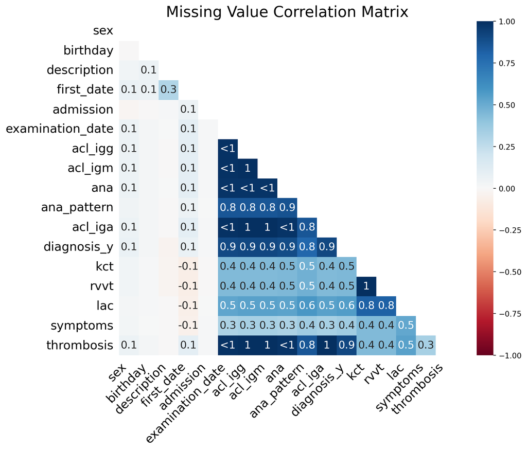

Figure 1: Missing Value Correlation Matrix

```python
merged_df = pd.merge(tsumoto_a, tsumoto_b, on='id', how='left')

%matplotlib inline

missing_value = msno.heatmap(merged_df, figsize=(10, 8))
missing_value.set_title("Missing Value Correlation Matrix", fontsize=20)
plt.savefig("missing_value_correlation_matrix.png", dpi=300, bbox_inches='tight')
plt.show()
```

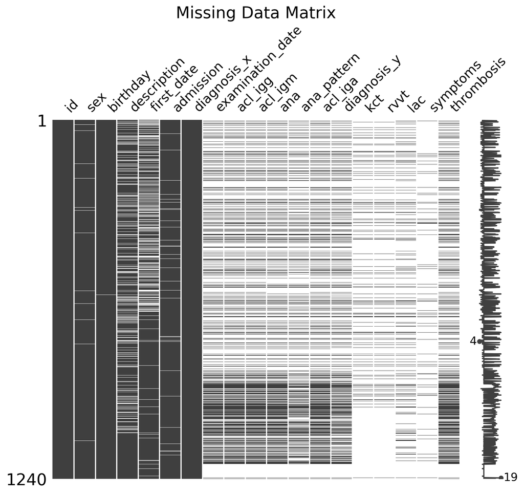

Figure 2: Missing Data Matrix

```python
# check the missing value pattern
%matplotlib inline


# Plot the missingno matrix on the created figure
missing_value = msno.matrix(merged_df, figsize=(10, 8))
missing_value.set_title("Missing Data Matrix", fontsize=20)
# Save the plot
plt.savefig("Missing_Data_Matrix", dpi=300, bbox_inches='tight')
# Show the plot
plt.show()
```

The merged tables such as Figure 1 and Figure 2 reveal that there are several missing values in the original data. If we want to analyze a specific variable, but there are missing values in that variable, we need to perform some preliminary processing of these missing values. To address this issue, we can use various techniques, such as imputation or deletion, to handle the missing values. In this case, we will use the deletion method to remove the missing values. The deletion method is a simple and straightforward method to handle missing values. It is a method of removing the missing values from the dataset.

```python
# drop rows with missing values in 'Thrombosis' column
merged_df_2 = merged_df.dropna(subset=['thrombosis'])
merged_df_2['examination_date'] = pd.to_datetime(
    merged_df['examination_date'], format='%Y/%m/%d')  # convert to datetime
merged_df_2['birthday'] = pd.to_datetime(
    merged_df['birthday'], format='%Y/%m/%d')  # convert to datetime
merged_df_2 = merged_df_2.reset_index(drop=True)  # reset index

# compute the difference between the two date columns
merged_df_2['age'] = ((merged_df_2['examination_date'] -
                      merged_df_2['birthday']).dt.days)/365
merged_df_2['age'] .fillna(0, inplace=True)
merged_df_2['age'] = merged_df_2['age'].astype(int)

merged_df_2.head()
```

|  | id | sex | birthday | description | first_date | admission | diagnosis_x | examination_date | acl_igg | acl_igm | ana | ana_pattern | acl_iga | diagnosis_y | kct | rvvt | lac | symptoms | thrombosis | age |
| --- | --- | --- | --- | --- | --- | --- | --- | --- | --- | --- | --- | --- | --- | --- | --- | --- | --- | --- | --- | --- |
| 0 | 14872 | F | 1953-09-21 | 97.08.13 | NaN | + | MCTD | 1997-05-27 | 1.3 | 1.6 | 256 | P | 0.0 | MCTD, AMI | NaN | NaN | - | AMI | 1.0 | 43 |
| 1 | 48473 | F | 1948-10-07 | 97.08.13 | NaN | + | SLE | 1992-12-21 | 4.3 | 4.6 | 256 | P,S | 3.3 | SLE | - | - | - | NaN | 0.0 | 44 |
| 2 | 102490 | F | 1982-04-01 | 94.02.22 | NaN | + | PSS | 1995-04-20 | 2.3 | 2.5 | 0 | NaN | 3.5 | PSS | NaN | NaN | NaN | NaN | 0.0 | 13 |
| 3 | 108788 | F | 1942-03-15 | NaN | NaN | + | SJS | 1997-05-06 | 0.0 | 0.0 | 16 | S | 0.0 | NaN | NaN | NaN | - | NaN | 0.0 | 55 |
| 4 | 122405 | F | 1961-05-22 | NaN | NaN | - | SJS | 1998-04-02 | 0.0 | 4.0 | 4 | P | 0.0 | SLE, SjS, vertigo | NaN | NaN | NaN | NaN | 0.0 | 36 |

My objective is to study the potential correlation between gender, age and thrombosis. I am utilizing two datasets - tsumoto_a, which includes information about the patient’s gender and date of birth, and tsumoto_b, which contains details regarding whether the patient has thrombosis and the severity of the condition. To investigate this relationship, I merged the two datasets by ID and removed the rows where thrombus data was missing. This merged dataset will help me in analyzing the correlation between gender, age, and the severity of thrombosis.

```python
new_table = pd.merge(merged_df_2, tsumoto_c, on='id', how='right')
new_table_1 = new_table[['id', 'igg', 'igm', 'iga', 'thrombosis']]
new_table_1.dropna(inplace=True)

new_table_1['igg'] = pd.to_numeric(new_table_1['igg'], errors='coerce')
new_table_1['igm'] = pd.to_numeric(new_table_1['igm'], errors='coerce')
new_table_1['iga'] = pd.to_numeric(new_table_1['iga'], errors='coerce')

new_table_1.loc[(new_table_1['igg'] > 900) & (
    new_table_1['igg'] < 2000), 'igg_level'] = 0
new_table_1.loc[(new_table_1['igg'] <= 900) | (
    new_table_1['igg'] >= 2000), 'igg_level'] = 1

new_table_1.loc[(new_table_1['igm'] > 40) & (
    new_table_1['igm'] < 400), 'igm_level'] = 0
new_table_1.loc[(new_table_1['igm'] <= 40) | (
    new_table_1['igm'] >= 400), 'igm_level'] = 1

new_table_1.loc[(new_table_1['iga'] > 80) & (
    new_table_1['iga'] < 500), 'iga_level'] = 0
new_table_1.loc[(new_table_1['iga'] <= 80) | (
    new_table_1['iga'] >= 500), 'iga_level'] = 1

new_table_2 = new_table_1.iloc[:, [0, -4, -3, -2, -1]]
new_table_2['thrombosis'] = new_table_2['thrombosis'].replace(
    {1.0: 1, 2.0: 1, 3.0: 1})  # 1: Positive, 0: Negative


new_table_2 = new_table_2.drop_duplicates(subset=['id'], keep='first')
new_table_2 = new_table_2.reset_index(drop=True)  # reset index

new_table_2.head()
```

|  | id | thrombosis | igg_level | igm_level | iga_level |
| --- | --- | --- | --- | --- | --- |
| 0 | 14872 | 1.0 | 0.0 | 0.0 | 0.0 |
| 1 | 48473 | 0.0 | 1.0 | 0.0 | 0.0 |
| 2 | 102490 | 0.0 | 1.0 | 0.0 | 1.0 |
| 3 | 108788 | 0.0 | 1.0 | 0.0 | 0.0 |
| 4 | 122405 | 0.0 | 1.0 | 0.0 | 0.0 |

## Exploratory analysis

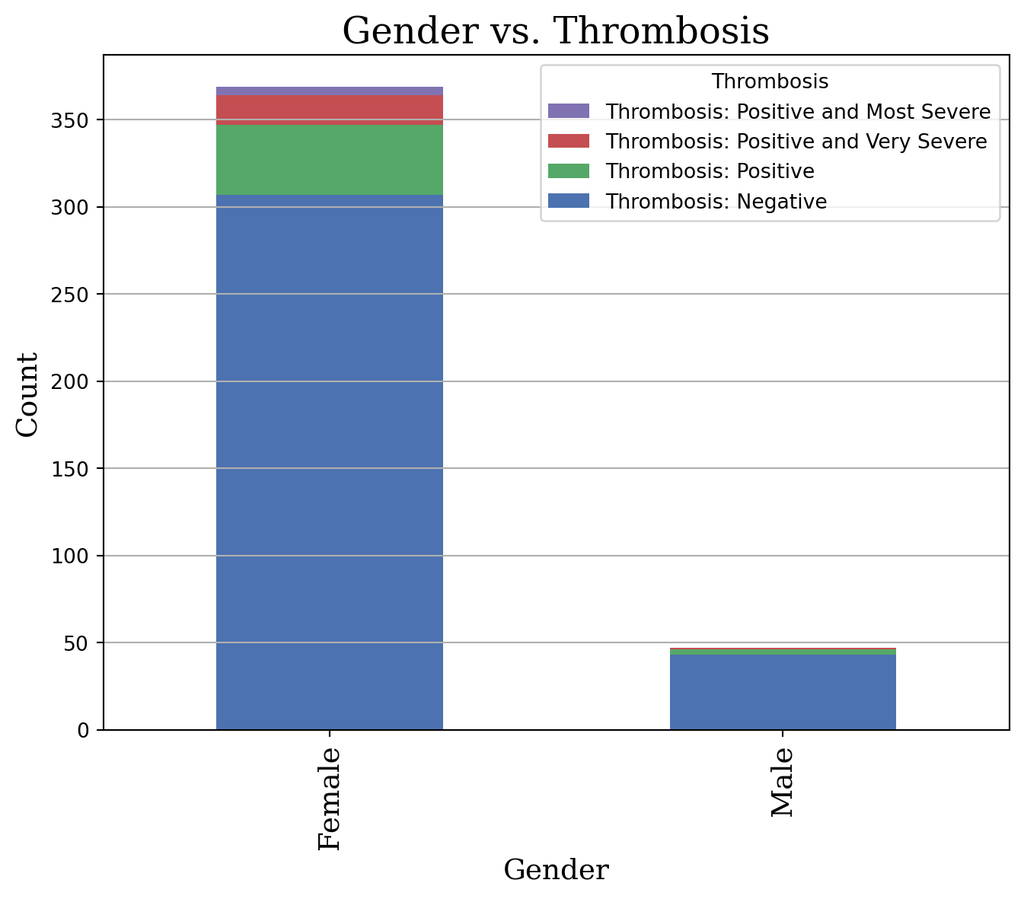

Figure 3: Gender vs. Thrombosis

```python
# create a crosstab table
crosstab = pd.crosstab(merged_df_2['sex'], merged_df_2['thrombosis'])

# set color palette
colors = ['#4C72B0', '#55A868', '#C44E52', '#8172B2']

# plot a stacked bar chart with specified colors
fig, ax = plt.subplots(figsize=(8, 6))
crosstab.plot(kind='bar', stacked=True, color=colors, ax=ax)

# add legend
handles, labels = ax.get_legend_handles_labels()
labels = ['Thrombosis: Negative', 'Thrombosis: Positive',
          'Thrombosis: Positive and Very Severe', 'Thrombosis: Positive and Most Severe']
ax.legend(reversed(handles), reversed(labels), title='Thrombosis', loc='best')

ax.set_xticklabels(['Female', 'Male'], fontname='serif', fontsize=14)
# add title and axis labels with serif font
plt.title('Gender vs. Thrombosis', fontname='serif', fontsize=18)
plt.xlabel('Gender', fontname='serif', fontsize=14)
plt.ylabel('Count', fontname='serif', fontsize=14)

# add grid
plt.grid(axis='y')

# save the plot
plt.savefig("plot-01.png", dpi=300, bbox_inches='tight')
# show the plot
plt.show()
```

In addition to the missing value analysis, several figures were generated to explore the relationships between different variables. Figure 3 shows the relationship between gender and thrombus occurrence, which is a crucial factor for thrombosis development.

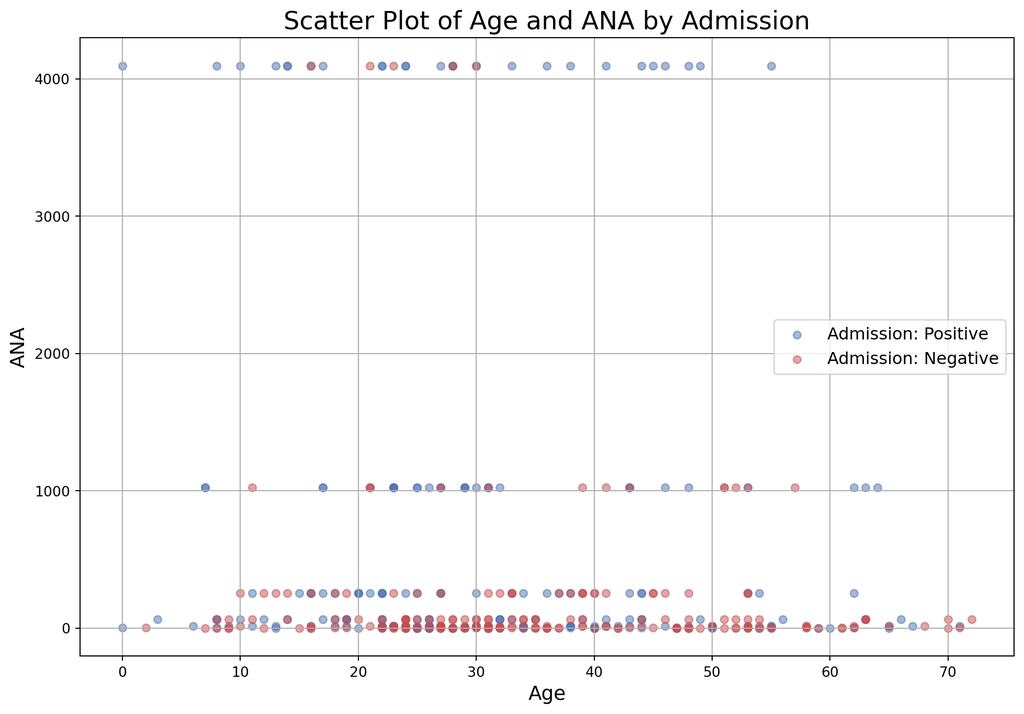

Figure 4: Scatter Plot of Age and ANA by Admission

```python
# create a crosstab table
pos_mask = merged_df_2['admission'] == '+'
neg_mask = merged_df_2['admission'] == '-'
merged_df_2['age'] = merged_df_2['age'].astype(float)
merged_df_2['ana'] = merged_df_2['ana'].astype(float)


# create a scatter plot
fig, ax = plt.subplots(figsize=(12, 8))
ax.scatter(merged_df_2.loc[pos_mask, 'age'], merged_df_2.loc[pos_mask,
           'ana'], label='Admission: Positive', alpha=0.5, s=30)
ax.scatter(merged_df_2.loc[neg_mask, 'age'], merged_df_2.loc[neg_mask,
           'ana'], label='Admission: Negative', alpha=0.5, s=30)

# set axis labels and title
ax.set_xlabel('Age', fontsize=14)
ax.set_ylabel('ANA', fontsize=14)
ax.set_title('Scatter Plot of Age and ANA by Admission', fontsize=18)

# add legend and grid
ax.legend(fontsize=12, loc='center right')
ax.grid(True)

# show the plot
plt.dpi = 200
plt.savefig("plot-02.png", dpi=300, bbox_inches='tight')
plt.show()
```

Figure 4 presents the correlation between admission age and ANA test results. The results of the ANA test can indicate if a person has an autoimmune disorder, which is often associated with thrombosis.

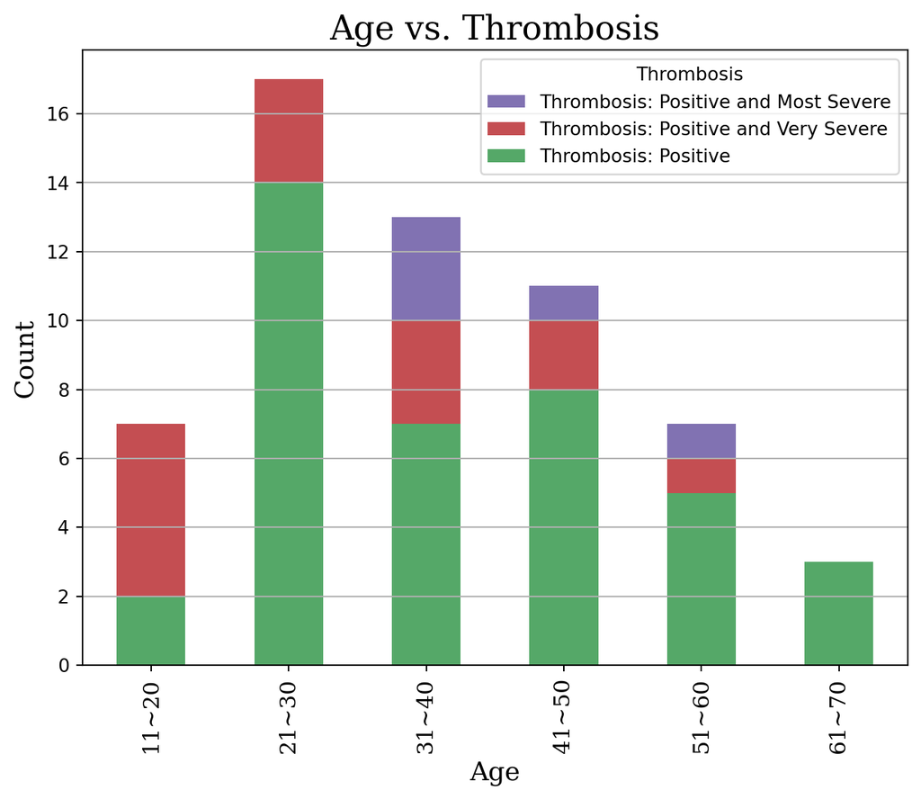

Figure 5: Age vs. Thrombosis

```python
filtered_df = merged_df_2[(merged_df_2['thrombosis']
                           != 0.0) & (merged_df_2['age'] > 0)]

# Create age groups
age_groups = pd.cut(filtered_df['age'], bins=[10, 20, 30, 40, 50, 60, 70, 80])

# Create a crosstab table
crosstab = pd.crosstab(age_groups, filtered_df['thrombosis'])

# Set color palette
colors = ['#55A868', '#C44E52', '#8172B2']

# Plot a stacked bar chart with specified colors
fig, ax = plt.subplots(figsize=(8, 6))
crosstab.plot(kind='bar', stacked=True, color=colors, ax=ax)

# Add legend
handles, labels = ax.get_legend_handles_labels()
labels = ['Thrombosis: Positive', 'Thrombosis: Positive and Very Severe',
          'Thrombosis: Positive and Most Severe']
ax.legend(reversed(handles), reversed(labels), title='Thrombosis', loc='best')

# Add title and axis labels with serif font
plt.title('Age vs. Thrombosis', fontname='serif', fontsize=18)
plt.xlabel('Age', fontname='serif', fontsize=14)
plt.ylabel('Count', fontname='serif', fontsize=14)

# Format x-axis labels
labels = ['11~20', '21~30', '31~40', '41~50', '51~60', '61~70']
ax.set_xticklabels(labels, fontname='serif', fontsize=12)

# Add grid
plt.grid(axis='y')
# Save the plot
plt.savefig("plot-03.png", dpi=300, bbox_inches='tight')
# Show the plot
plt.show()
```

Figure 5 displays the distribution of thrombosis cases across different age ranges. This information can help us understand which age groups are more prone to thrombosis.

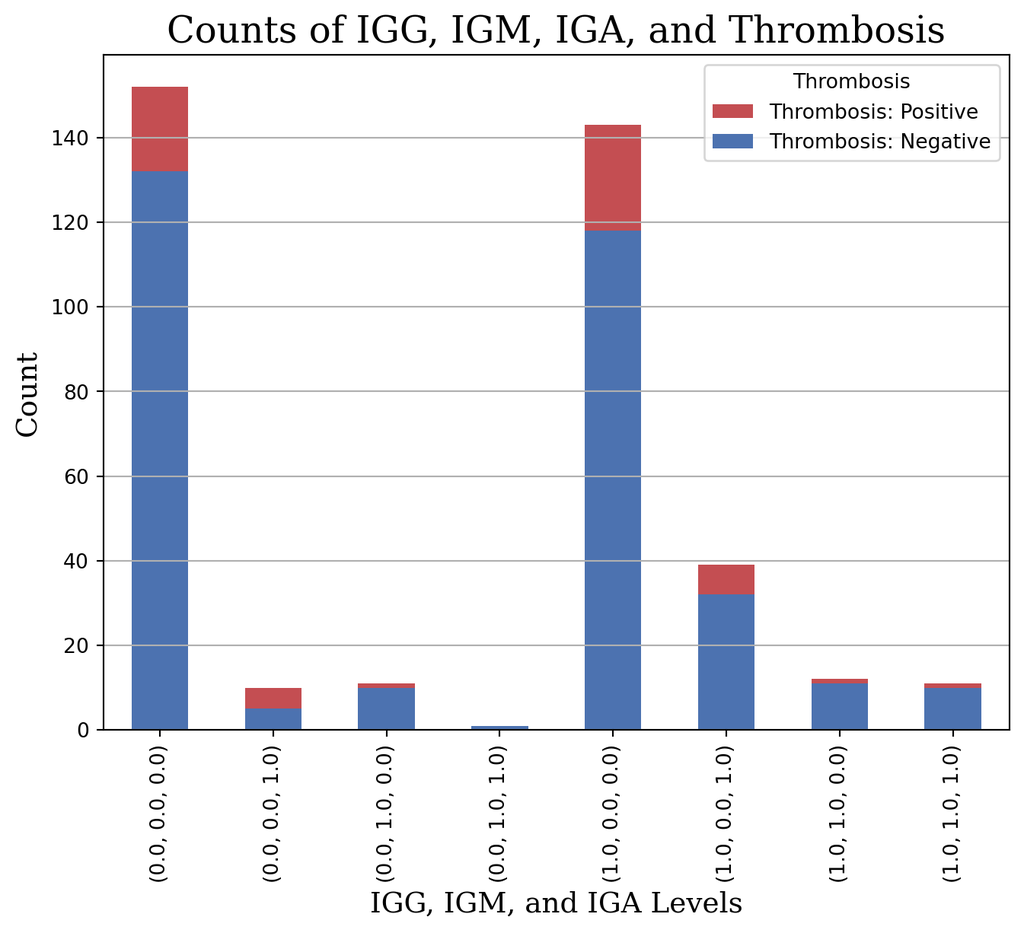

Figure 6: Counts of IGG, IGM, IGA, and Thrombosis

```python
# create a crosstab table
crosstab = pd.crosstab([new_table_2['igg_level'], new_table_2['igm_level'],
                       new_table_2['iga_level']], new_table_2['thrombosis'])

# set color palette
colors = ['#4C72B0', '#C44E52']

# plot a stacked bar chart with specified colors
sns.set_palette(colors)
ax = crosstab.plot(kind='bar', stacked=True, figsize=(8, 6))

# add legend
handles, labels = ax.get_legend_handles_labels()
labels = ['Thrombosis: Negative', 'Thrombosis: Positive']
ax.legend(reversed(handles), reversed(labels), title='Thrombosis', loc='best')

# add title and axis labels with serif font
plt.title('Counts of IGG, IGM, IGA, and Thrombosis',
          fontname='serif', fontsize=18)
plt.xlabel('IGG, IGM, and IGA Levels', fontname='serif', fontsize=14)
plt.ylabel('Count', fontname='serif', fontsize=14)

# add grid
plt.grid(axis='y')
# save the plot
plt.savefig("plot-04.png", dpi=300, bbox_inches='tight')
# show the plot
plt.show()
```

Finally, Figure 6 shows the association between normal/abnormal IGG, IGM, and IGA levels and the occurrence of thrombosis. These three immunoglobulin classes are known to be closely linked to the development of thrombosis, and their levels are thus a key factor in thrombosis risk assessment. There are three numbers of one kind on the x-axis. They represent the levels of IGG, IGM, and IGA respectively. 0 means the test result is in the normal range and 1 means it is not.

# Technical summary

The purpose of this study was to examine the relationship between anti-Cardiolipin antibodies and thrombosis using data from three different sources. The data sets were merged based on a shared ID column, and the analysis involved multiple steps, including data cleaning, handling of missing data, and visualization of the relationships between various variables.

Our study found that visualizations, such as heatmaps and scatterplots, were particularly helpful in identifying patterns and relationships between different variables. However, some visualizations, such as bar plots, were less effective in exploring relationships between variables.

In conclusion, this study provides important insights into the relationship between anti-Cardiolipin antibodies and thrombosis. Thorough data cleaning and visualization are crucial in exploring complex relationships between multiple variables. By identifying the factors that are most closely associated with thrombosis, our analysis can guide future research and clinical interventions to reduce the risk of thrombosis among patients with anti-Cardiolipin antibodies.

To investigate the temporal relationships between anti-Cardiolipin antibodies, thrombosis, and other relevant variables, future research should consider incorporating additional data. Moreover, further research should examine additional potential predictors of thrombosis, such as comorbidities or lifestyle factors, to gain a more comprehensive understanding of this complex phenomenon.